# The Hyperlink Analysis on Instagram API Documentation

Weiquan Luo

2019-10-01

# 1. Documentation

## 1.1 Highlight

- Discover the structure of a online documentation
- Apply webscapying toolkit (R package `rvest`, similar to `bs4` in python) with HTML tag and CSS selector to scrap information from online pages.
- Use functional programming toolkit (R package `purrr`) to duplicate the same operation on a list of value
- Use parallel computing (R package `furrr`) to speed up the functional programming method about 5 time.

## 1.2 Method

I take “https://www.instagram.com/developer/” as the base url to navigate all pages under this base url as well as their direct-linked pages not under the base. The scraping is done by parallel processing on multi-cores and functional programming method. The information obtained from the scraping is the hyperlink with html tag `a`, title of the page with html tag `title`, the first header with html tag `h1`. The obtained dataset is store in two data frame. The data frame `elist` contains edge information: variable `From` is the page url and variable `To` is the hyperlinks in the page. The data frame `Vattrs` contain vertex information: variable `names` is the page url; the variable `title` is the title of the url; the variable `h1` is the first header of the url.

## 1.3 A Little more Story Why Doing this.

My goal of this web scraping assignment is to challenge myself on nagivating a large website by using only coding and scraping useful information. I was really interested in API scraping, so I try to read the tweeter API documentation and that is so difficult to understand because the page layout and hyperlink connection are so confusing. Besides, the description is not helpfull at all. So I compared the tweeter API documentation with Facebook, Microsoft, Linkedin, and Instagram. I found the one by Instagram is really easy to understand. So I perform a network data analysis on the Hyperlink connection across the Instagram API Documentation.

# 2. Discussion & Code

## 2.1 Prerequisites

```r
library(rvest)
library(tibble)
library(stringr)
library(dplyr)
source("ud_funcion.R")
```

```r
library(furrr) # purrr::map_dfr == furrr::future_map_dfr
plan(multiprocess) # switch to parallel computing
```

## 2.2 scrapEdge

```r
# the base url
url <- "https://www.instagram.com/developer/"

ptm <- proc.time() # initial timming
repeat {
  # dynamic plot during scraping
  # flush.console()
  if (exists("monitor") == FALSE){ # for the first url
    # find all href for this url
    elist <- scrapEdge(url) %>% na.omit()
    # find nav href for a html url
    elist_nav_raw <- scrapEdge_nav(url) %>% select(To) %>% as.vector()
    elist_nav_raw <- elist_nav_raw[!elist_nav_raw == url]
    # construct monitor(time,links)
    monitor <- data.frame(time = as.vector((proc.time() - ptm)[3]),
                          links = nrow(elist))
  }
  # rbind elist
  elist <- rbind(elist, furrr::future_map_dfr(elist$To[str_detect(elist$To, url)] %>% unique() %>% na.omit(),
                                              scrapEdge)) %>%
    distinct()
  # rbind monitor
  monitor <- rbind(monitor,
                   data.frame(time = as.vector((proc.time() - ptm)[3]),
                              links = nrow(elist)))
  # dynamic plot
  # plot(monitor$time,monitor$links,type='l', xlim=c(0,max(monitor$time)),
  #      xlab="Time in seconds", ylab="Number of href Links")
  # title(paste0("Scraping Hyperlink Connection: ", url))

  # break criterion
  if (length(unique(tail(monitor$links,2))) == 1 & nrow(monitor)>=2){
    break
  }
  if (max(monitor$links) > 2000){
    break
  }
}
```

```
## ERROR : HTTP error 404.   https://www.instagram.com/developer/limits/
## ERROR : HTTP error 404.   https://www.instagram.com/developer/embedding/NA
## ERROR : HTTP error 404.   https://www.instagram.com/developer/limits/
## ERROR : HTTP error 404.   https://www.instagram.com/developer/embedding/NA
## ERROR : HTTP error 404.   https://www.instagram.com/developer/endpoints/users/NA
## ERROR : HTTP error 404.   https://www.instagram.com/developer/endpoints/comments/NA
## ERROR : HTTP error 404.   https://www.instagram.com/developer/limits/
## ERROR : HTTP error 404.   https://www.instagram.com/developer/embedding/NA
## ERROR : HTTP error 404.   https://www.instagram.com/developer/endpoints/users/NA
## ERROR : HTTP error 404.   https://www.instagram.com/developer/endpoints/comments/NA
```

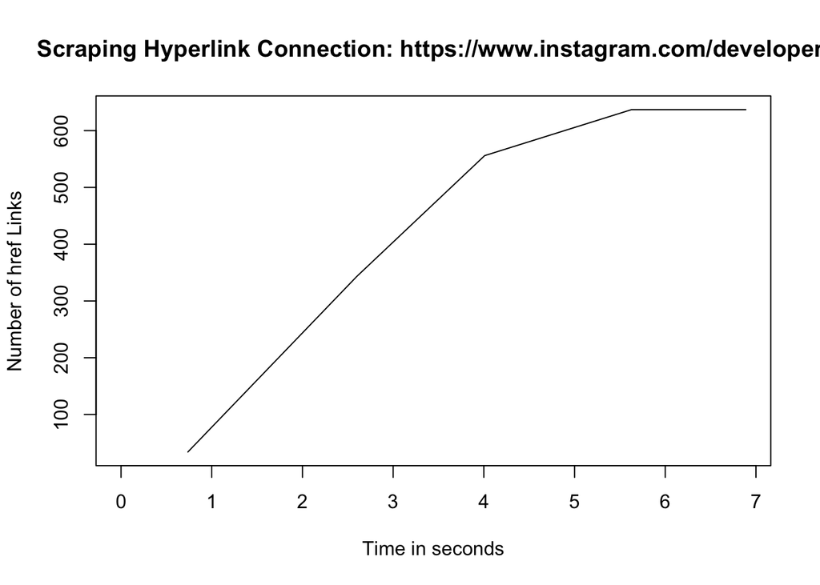

```r
# plot
plot(monitor$time,monitor$links,type='l', xlim=c(0,max(monitor$time)),
     xlab="Time in seconds", ylab="Number of href Links")
title(paste0("Scraping Hyperlink Connection: ", url))
```

```r
elist_nav <- elist %>% filter(From %in% elist_nav_raw & To %in% elist_nav_raw) # edge list in navigation bar
elist_wo_nav <- setdiff(elist, elist_nav) # edge list not in navigation bar
# show all elist
elist
```

```
## # A tibble: 637 x 3
##    From                    To                                 linkName
##    <chr>                   <chr>                              <chr>
##  1 https://www.instagram.… https://www.instagram.com/         Instagram
##  2 https://www.instagram.… https://www.instagram.com/account… Login
##  3 https://www.instagram.… https://www.instagram.com/develop… Overview
##  4 https://www.instagram.… https://www.instagram.com/develop… Authenticati…
##  5 https://www.instagram.… https://www.instagram.com/develop… LoginPermiss…
##  6 https://www.instagram.… https://www.instagram.com/develop… PermissionsR…
##  7 https://www.instagram.… https://www.instagram.com/develop… SandboxMode
##  8 https://www.instagram.… https://www.instagram.com/develop… SecureReques…
##  9 https://www.instagram.… https://www.instagram.com/develop… Endpoints
## 10 https://www.instagram.… https://www.instagram.com/develop… Embedding
## # … with 627 more rows
```

```r
# show vertex attributes
vattrs <- scrapVertex(elist); vattrs # find attrs for elist
```

```
## # A tibble: 69 x 3
##    Name                           Title                      h1
##    <chr>                          <chr>                      <chr>
##  1 https://www.instagram.com/dev… InstagramDeveloperDocumen… HelloDevelope…
##  2 https://www.instagram.com/dev… InstagramDeveloperDocumen… Authentication
##  3 https://www.instagram.com/dev… InstagramDeveloperDocumen… LoginPermissi…
##  4 https://www.instagram.com/dev… PermissionsReview•Instagr… PermissionsRe…
##  5 https://www.instagram.com/dev… SandboxMode•InstagramDeve… SandboxMode
##  6 https://www.instagram.com/dev… SecureRequests•InstagramD… SecureRequests
##  7 https://www.instagram.com/dev… APIEndpoints•InstagramDev… APIEndpoints
##  8 https://www.instagram.com/dev… InstagramDeveloperDocumen… Embedding
##  9 https://www.instagram.com/dev… MobileSharing•InstagramDe… MobileSharing
## 10 https://www.instagram.com/dev… Libraries•InstagramDevelo… Libraries
## # … with 59 more rows
```

```r
plan(sequential) # back to sequential computing
```

## 2.3 plot network data

```r
library(igraph)
```

The network with only navigation bar connection show that there are higth inter-connection between each other. The network without navigation bar connection show high degree of connection between the subpage to the navigational bar

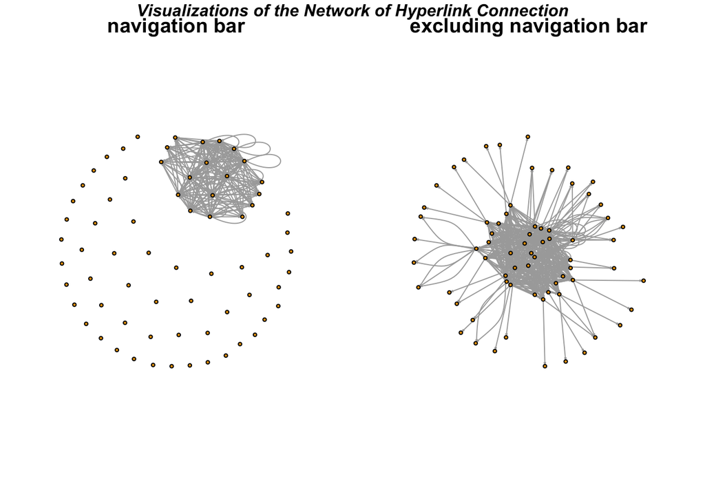

```r
igraph.options(vertex.size=3, vertex.label=NA, edge.arrow.size=0.1)
par(mfrow=c(1,2), mar = c(2.5,2.5,2.5, 2.5))
# igraph elist_nav
g <- graph.data.frame(elist_nav,
                      directed="TRUE",
                      vertices=vattrs)
plot(g, vertex.label=NA,
     layout=layout.kamada.kawai, main = "navigation bar")

# igraph elist_wo_nav
g <- graph.data.frame(elist_wo_nav,
                      directed="TRUE",
                      vertices=vattrs %>% select(Name,Title))
plot(g, vertex.label=NA,
     layout=layout.kamada.kawai, main = "excluding navigation bar")
mtext("Visualizations of the Network of Hyperlink Connection", outer=TRUE,  cex=1, line=-1, font = 4)
```

The following network visualization with different layout show the network data has the hierarchy sturcture.

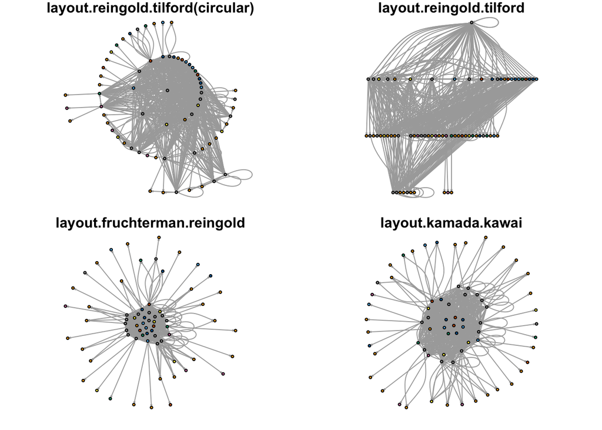

```r
# igraph elist
g <- graph.data.frame(elist,
                      directed="TRUE",
                      vertices=vattrs)
g$name <- paste0("Hyperlink Connection: ", url)
vertex.c <- as.numeric(as.factor(V(g)$Title)) # use attr Practice to coloring
Title.size <- as.vector(table(V(g)$Title))
par(mfrow=c(2,2), mar=c(1, 1, 1, 1))
igraph.options(vertex.size=3, vertex.label=NA, edge.arrow.size=0.1)
plot(g, vertex.color=vertex.c, vertex.label=NA,
     layout=layout.reingold.tilford(g, circular=T),
     main="layout.reingold.tilford(circular)")
plot(g, vertex.color=vertex.c, vertex.label=NA,
     layout=layout.reingold.tilford,
     main="layout.reingold.tilford")
plot(g, vertex.color=vertex.c, vertex.label=NA,
     layout=layout.fruchterman.reingold,
     main="layout.fruchterman.reingold")
plot(g, vertex.color=vertex.c, vertex.label=NA,
     layout=layout.kamada.kawai,
     main="layout.kamada.kawai")
```

The greatest number of links across the documentation website are the login link `Login Instagram` and index page of the documentation`Instagram Developer Documentation`. The following is the HTTP 404 error, which the bad pages.

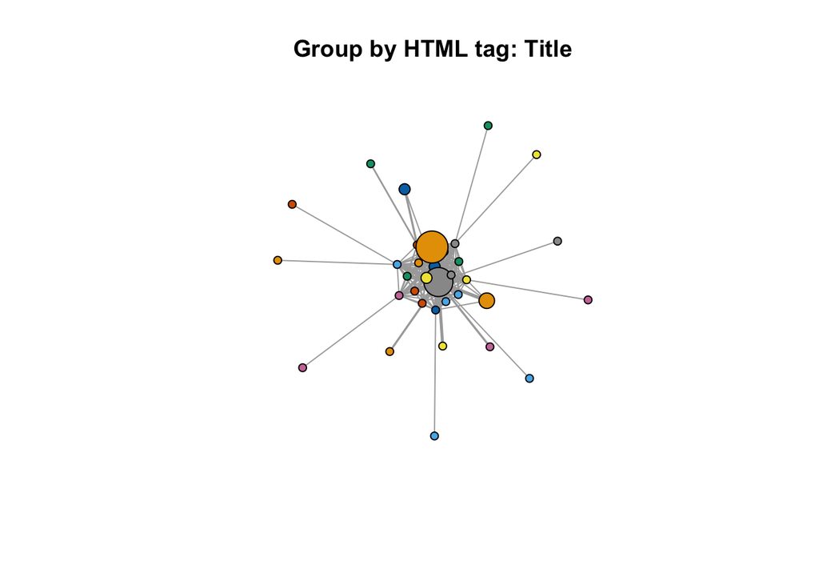

```r
g.c <- contract.vertices(as.undirected(g), vertex.c) # Contract several vertices into a single one
E(g.c)$weight <- 1 # assign 1 to the weight of each edge
g.c <- igraph::simplify(g.c) # convert from multigraph to simple graph
# explore how much department communicate to each other
Title.names <- sort(unique(V(g)$Title))
plot(g.c, vertex.size=5*sqrt(Title.size),
     vertex.label = NA,
     vertex.color=V(g.c),
     edge.width=sqrt(E(g.c)$weight),
     vertex.label.dist=1.5,
     edge.arrow.size=0,
     main = "Group by HTML tag: Title")
```

```r
tibble(Title = Title.names, n = Title.size) %>% arrange(desc(n))
```

```
## # A tibble: 34 x 2
##    Title                                                         n
##    <chr>                                                     <int>
##  1 Login•Instagram                                              17
##  2 InstagramDeveloperDocumentation                              14
##  3 "Error in open.connection(x, \"rb\") : HTTP error 404.\n"     4
##  4 Instagram                                                     2
##  5 InstagramPlatformAPIforDevelopers|FacebookforDevelopers       2
##  6 PermissionsReview•InstagramDeveloperDocumentation             2
##  7 AboutDocumentInteraction                                      1
##  8 AboutUs•Instagram                                             1
##  9 AndroidIntents•InstagramDeveloperDocumentation                1
## 10 APIEndpoints•InstagramDeveloperDocumentation                  1
## # … with 24 more rows
```

## 2.4 Descriptive Analysis

### 2.4.1 Vertex Degree Distribution

There is more out connection compare to the in connection. It shows the degree documentation using external resouce relative to the internal resource. Noticeably, there are more url has number of hyperlink less than ten than that more than 20, which show a hierarchy sturcture.

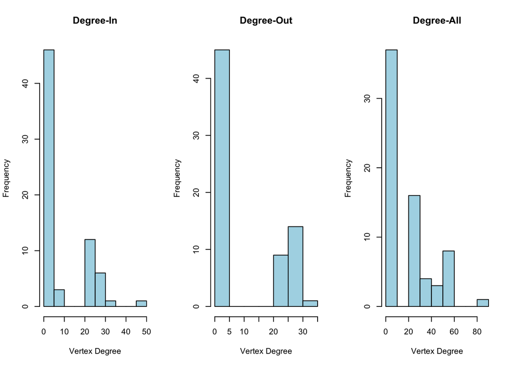

```r
# VertexD egree
par(mfrow=c(1,3))
hist(igraph::degree(g, mode="in"), col="lightblue",
     xlab="Vertex Degree", ylab="Frequency", main="Degree-In")
hist(igraph::degree(g, mode="out"), col="lightblue",
     xlab="Vertex Degree", ylab="Frequency", main="Degree-Out")
hist(igraph::degree(g, mode="all"), col="lightblue",
     xlab="Vertex Degree", ylab="Frequency", main="Degree-All")
```

### 2.4.2 Vertex Centrality

```r
library(sna)
```

- `degree` centrality shows there distinguish three type of url in this website, which are navigational page, detail guide page, and external page.
- `Closeness` centrality shows some vertice are more ‘central’ becaise they are close to many other vertices
- `Betweenness` centrality shows only a few vertice are located between (on the path) other pairs of vertices
- `eigenvector` centrality show haft of the vertice are more central the neighbors of a vertex are, therefore, the more central that vertex itself is.

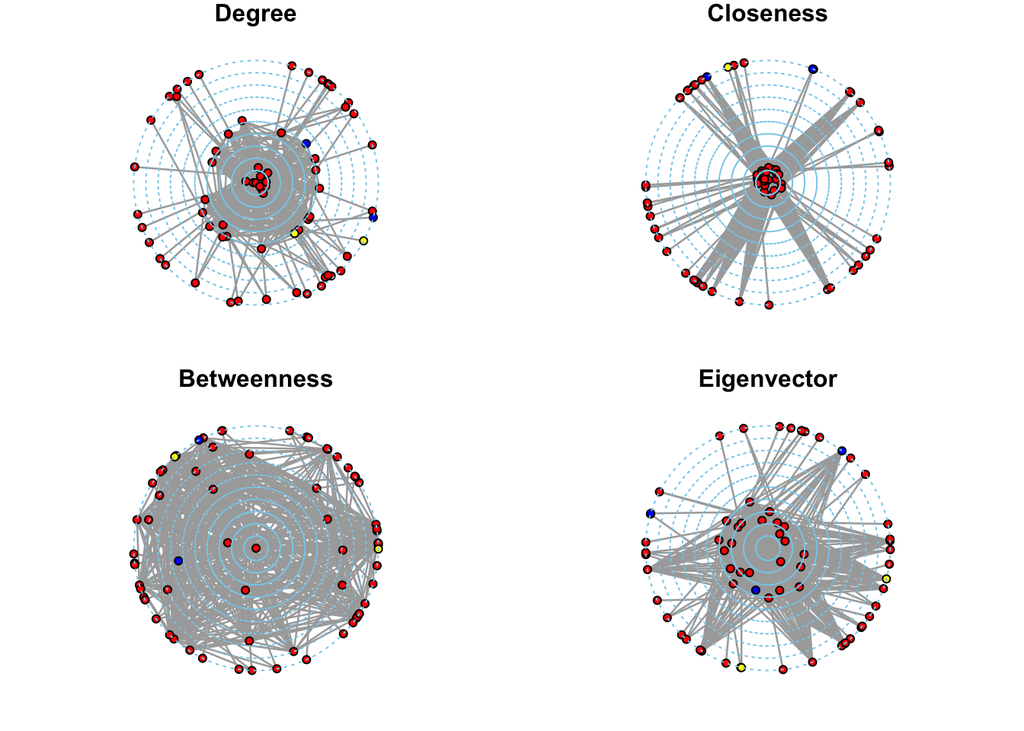

```r
# VertexCentrality
A <- get.adjacency(g, sparse=FALSE)
library(network)
g.netmat <- network::as.network.matrix(A)
# The head teacher and instructor are indicated with blue and yellow, respectively
par(mfrow=c(2,2), mar=c(1, 1, 1, 1))
sna::gplot.target(g.netmat, degree(g.netmat),
                  main="Degree", circ.col="skyblue",
                  usearrows = FALSE, circ.lab = FALSE,
                  vertex.col=c("blue", rep("red", 32), "yellow"),
                  edge.col="darkgray")
sna::gplot.target(g.netmat, closeness(g.netmat),
                  main="Closeness", circ.col="skyblue",
                  usearrows = FALSE, circ.lab = FALSE,
                  vertex.col=c("blue", rep("red", 32), "yellow"),
                  edge.col="darkgray")
sna::gplot.target(g.netmat, betweenness(g.netmat),
                  main="Betweenness", circ.col="skyblue",
                  usearrows = FALSE, circ.lab = FALSE,
                  vertex.col=c("blue", rep("red", 32), "yellow"),
                  edge.col="darkgray")
sna::gplot.target(g.netmat, evcent(g.netmat),
                  main="Eigenvector", circ.col="skyblue",
                  usearrows = FALSE, circ.lab = FALSE,
                  vertex.col=c("blue", rep("red", 32), "yellow"),
                  edge.col="darkgray")
```

- `hub.score` score the importance of so-called hub vertices by how many authority vertices they point to, according to the eigenvector centrality of the matrix M_hub = A A^T
- `authority.score` scores the importance of so-called authority vertices by how many hubs point to them, according to the eigenvector centrality of the matrix M_auth = A^T A.

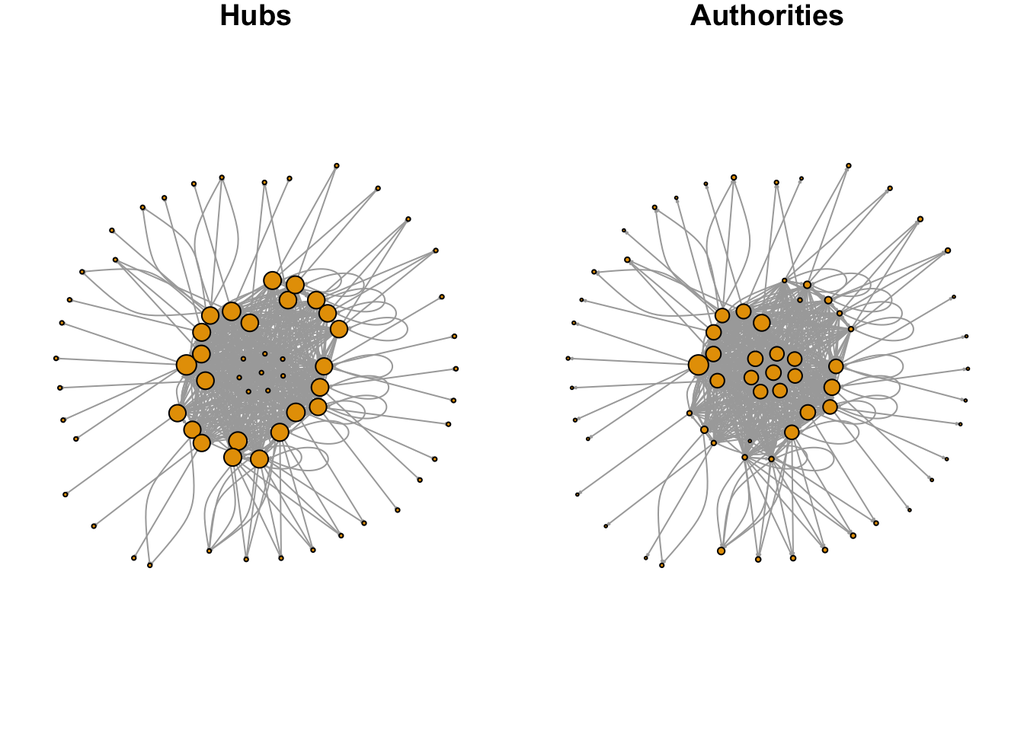

```r
par(mfrow=c(1,2), mar=c(1, 1, 1, 1))
l <- layout.kamada.kawai(g)
plot(g, layout=l, main="Hubs", vertex.label="",
     vertex.size=10 * sqrt(hub.score(g)$vector))
plot(g, layout=l,
     main="Authorities", vertex.label="",
     vertex.size=10 * sqrt(authority.score(g)$vector))
```

# 3. Interactive network (only valid in HTML)

```r
library(visNetwork)
# convert igraph to VisNetwork Data
data <- toVisNetworkData(g)
# add characteristic
data$nodes <- data$nodes %>%
  mutate(group = Title) %>%  # add grouping variable
  mutate(title = paste0("<p> id <br>", id, "</p>", "<p> Title <br>", Title, "</p>"),
         stringsAsFactors = FALSE) #add tooltip (pop-up) variable
# ploting
visNetwork(nodes = data$nodes,
           edges = data$edges,
           height = "500px") %>%
  # grouping
  visGroups(groupname = "InstagramDeveloperDocumentation", color = "blue", shape = "star") %>%
  # layout
  visIgraphLayout(layout = "layout.kamada.kawai") %>%
  # options
  visOptions(highlightNearest = list(enabled = T, hover = T),
             nodesIdSelection = T)
```

[interactive chart not shown]

# A. Appendix: ud_funcion.R

```r
cleanText <- function(x){
  x <- gsub("[[:blank:]]", "", x)
  x <-  gsub("\n", "", x) # clean up the links names
  return(x)
}

# find all href for a html url
scrapEdge <- function(url) {
  tryCatch({
    html <- read_html(url) # parse to html
    links <- html %>% html_nodes('a') %>% html_attr(name="href"); links # obtain the href
    linkName <- html %>% html_nodes('a') %>% html_text() %>% cleanText() # obtain the href text
    elist <- tibble(From = rep(url,length(links)),
                    To = url_absolute(links,url) %>% as.character(),
                    linkName = linkName ) %>%
      na.omit()# construct elist(From,To)
    return(elist)
  }, error = function(e) {cat("ERROR :",conditionMessage(e), " ", url, "\n")})
}

# find nav href for a html url
scrapEdge_nav <- function(url) {
  tryCatch({
    html <- read_html(url) # parse to html
    links <- html %>% html_nodes('nav a') %>% html_attr(name="href"); links # obtain the href
    linkName <- html %>% html_nodes('nav a') %>% html_text() %>% cleanText() # obtain the href text
    elist <- data.frame(From = rep(url,length(links)),
                        To = url_absolute(links,url) %>% as.character(),
                        linkName = linkName ,
                        stringsAsFactors = FALSE) %>%
      na.omit()# construct elist(From,To)
    return(elist)
  }, error = function(e) {cat("ERROR :",conditionMessage(e), " ", url, "\n")})
}

# scrap attrs for a url
scrapAttrs <- function(url){
  html <- try(read_html(url), silent = TRUE)
  if (class(html) != "try-error"){
    title <-html %>% html_node("title") %>% html_text() %>% cleanText()
    h1 <- html %>% html_node("h1") %>% html_text() %>% cleanText()
  } else {
    title <- html[1]
    h1 <- html[1]
  }
  vattr <- tibble(Name = url, Title = title, h1 = h1)
  return(vattr)
}

# scrap attrs for a list of url
scrapVertex <- function(elist){
  # construct a vector of url
  links <- append(as.vector(elist$From), as.vector(elist$To)) %>%
    unique() %>%
    na.omit()

  # scrapy attr for each html page
  vattrs <- furrr::future_map_dfr(links, function(x) try(scrapAttrs(x),silent = TRUE))
  return(vattrs)
}
```